# Data 607 Project 2

Jiaxin Zheng

2024-10-12

```r
library(knitr)
library(stringr)
library(tidyr)
library(dplyr)
library(tidyverse)
```

```r
library(ggplot2)
```

**Data 1** **First data is about the World Happiness Report in 2020. This data includes the Happiness Score for 153 countries. The Happiness Score is responses to the main life evaluation question asked in the Gallup World Poll(GWP). The Happiness Score is explained by the following factors: GDP per capita, Healthy Life Expectancy, Social support, Freedom to make life choices, Generosity, Corruption Perception, Residual error.**

```r
#view data 1

file1 <- "https://raw.githubusercontent.com/Jennyjjxxzz/Data-607_Project2/refs/heads/main/wide_data/World%20Happiness%20Report_20_DataForFigure2.1.csv"
df1 <- read.csv(file1)
head(df1)
```

```
##   Country.name Regional.indicator Ladder.score Standard.error.of.ladder.score
## 1      Finland     Western Europe       7.8087                     0.03115630
## 2      Denmark     Western Europe       7.6456                     0.03349229
## 3  Switzerland     Western Europe       7.5599                     0.03501417
## 4      Iceland     Western Europe       7.5045                     0.05961586
## 5       Norway     Western Europe       7.4880                     0.03483738
## 6  Netherlands     Western Europe       7.4489                     0.02779175
##   upperwhisker lowerwhisker Logged.GDP.per.capita Social.support
## 1     7.869766     7.747634              10.63927      0.9543297
## 2     7.711245     7.579955              10.77400      0.9559908
## 3     7.628528     7.491272              10.97993      0.9428466
## 4     7.621347     7.387653              10.77256      0.9746696
## 5     7.556281     7.419719              11.08780      0.9524866
## 6     7.503372     7.394428              10.81271      0.9391388
##   Healthy.life.expectancy Freedom.to.make.life.choices  Generosity
```

[output cut: 41 more lines]

**Question_1: Which region has the highest average happiness (Ladder score)?**

```r
#group by and plot the average
region_happiness <- df1 %>%
  group_by(Regional.indicator) %>%
  summarize(avg_ladder_score = mean(Ladder.score, na.rm = TRUE)) %>%
  arrange(desc(avg_ladder_score))
```

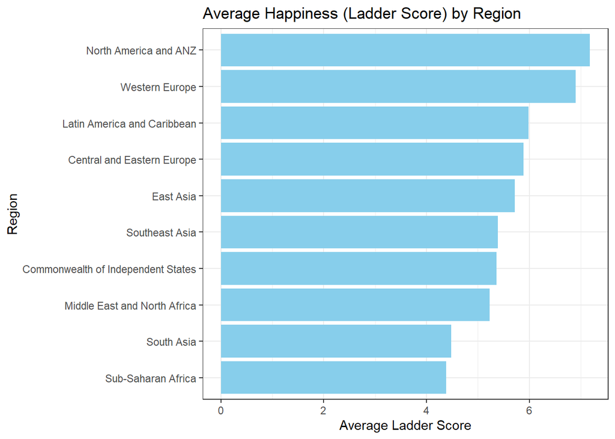

```r
ggplot(region_happiness, aes(x = reorder(Regional.indicator, avg_ladder_score), y = avg_ladder_score)) +
  geom_bar(stat = "identity", fill = "skyblue") +
  coord_flip() +
  labs(title = "Average Happiness (Ladder Score) by Region", x = "Region", y = "Average Ladder Score")+
  theme_bw()
```

**Question_2: Relationship between Ladder score and GDP, social support, and life expectancy**

```r
# Ladder score correlation analysis
ladder_score_correlations <- df1 %>%
  select(Ladder.score, Logged.GDP.per.capita, Social.support, Healthy.life.expectancy) %>%
  cor(use = "complete.obs")

print(ladder_score_correlations)
```

```
##                         Ladder.score Logged.GDP.per.capita Social.support
## Ladder.score               1.0000000             0.7753744      0.7650008
## Logged.GDP.per.capita      0.7753744             1.0000000      0.7818136
## Social.support             0.7650008             0.7818136      1.0000000
## Healthy.life.expectancy    0.7703163             0.8484686      0.7427441
##                         Healthy.life.expectancy
## Ladder.score                          0.7703163
## Logged.GDP.per.capita                 0.8484686
## Social.support                        0.7427441
## Healthy.life.expectancy               1.0000000
```

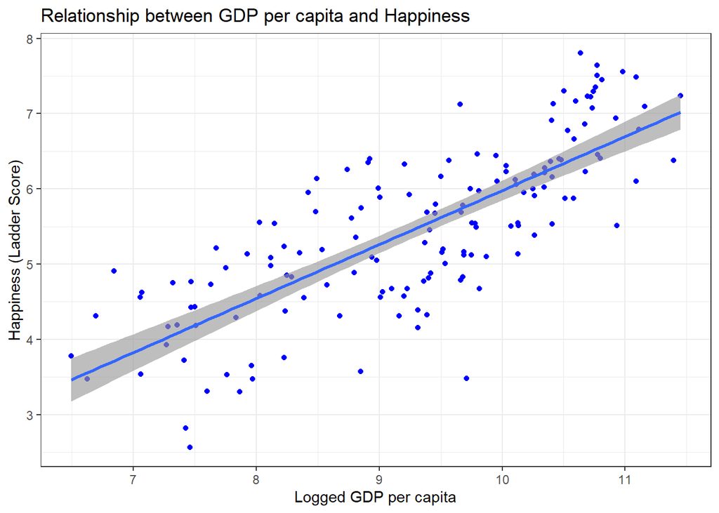

```r
# Plot relationship between Ladder score and GDP per capita
ggplot(df1, aes(x = Logged.GDP.per.capita, y = Ladder.score)) +
  geom_point(color = "blue") +
  geom_smooth(method = "lm", col = "red") +
  labs(title = "Relationship between GDP per capita and Happiness", x = "Logged GDP per capita", y = "Happiness (Ladder Score)")+
  geom_smooth(method = lm)+
  theme_bw()
```

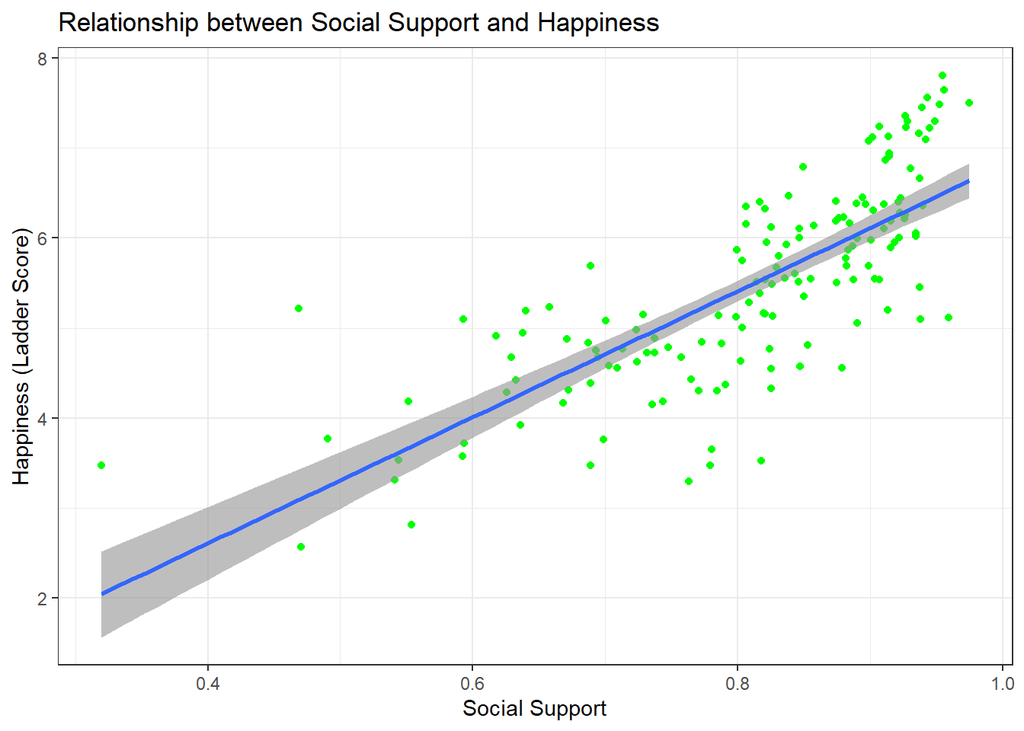

```r
# Plot relationship between Ladder score and Social support
ggplot(df1, aes(x = Social.support, y = Ladder.score)) +
  geom_point(color = "green") +
  geom_smooth(method = "lm", col = "red") +
  labs(title = "Relationship between Social Support and Happiness", x = "Social Support", y = "Happiness (Ladder Score)")+
  geom_smooth(method = lm)+
  theme_bw()
```

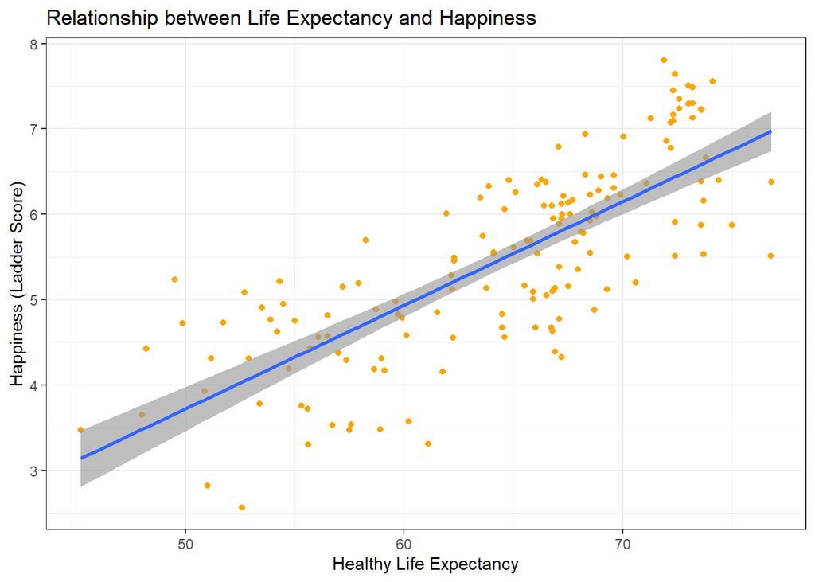

```r
# Plot relationship between Ladder score and Life expectancy
ggplot(df1, aes(x = Healthy.life.expectancy, y = Ladder.score)) +
  geom_point(color = "orange") +
  geom_smooth(method = "lm", col = "red") +
  labs(title = "Relationship between Life Expectancy and Happiness", x = "Healthy Life Expectancy", y = "Happiness (Ladder Score)")+
  geom_smooth(method = lm)+
  theme_bw()
```

**Result for data 1: The North America and ANZ region ranks as the happiest region globally base on the highest average Ladder Score. Also the data shows a strong relationship between social support. Supported by their community elevated the happiness level.**

**Data 2** **Second data show the ranking of the best universities of the world make by The Times Higher Education for 2020. The data frame consists of Rank char, Score Rank, University name, Country… .**

```r
#view data 2

file2 <- "https://raw.githubusercontent.com/Jennyjjxxzz/Data-607_Project2/refs/heads/main/wide_data/Word_University_Rank_2020.csv"
df2 <- read.csv(file2)
head(df2)
```

```
##   Rank_Char Score_Rank                            University        Country
## 1         1          1                  University of Oxford United Kingdom
## 2         2          2    California Institute of Technology  United States
## 3         3          3               University of Cambridge United Kingdom
## 4         4          4                   Stanford University  United States
## 5         5          5 Massachusetts Institute of Technology  United States
## 6         6          6                  Princeton University  United States
##   Number_students Numb_students_per_Staff International_Students
## 1          20,664                    11.2                    41%
## 2           2,240                     6.4                    30%
## 3          18,978                    10.9                    37%
## 4          16,135                     7.3                    23%
## 5          11,247                     8.6                    34%
## 6           7,983                     8.1                    25%
##   Percentage_Female Percentage_Male Teaching Research Citations Industry_Income
## 1               46%             54%     90.5     99.6      98.4            65.5
## 2               34%             66%     92.1     97.2      97.9            88.0
## 3               47%             53%     91.4     98.7      95.8            59.3
## 4               43%             57%     92.8     96.4      99.9            66.2
## 5               39%             61%     90.5     92.4      99.5            86.9
## 6               45%             55%     90.3     96.3      98.8            58.6
##   International_Outlook Score_Result Overall_Ranking
## 1                  96.4         95.4           95.40
## 2                  82.5         94.5           94.50
## 3                  95.0         94.4           94.40
## 4                  79.5         94.3           94.30
## 5                  89.0         93.6           93.60
## 6                  81.1         93.2           93.20
```

**Question_1: Which country has the most universities in the top 100?**

```r
#filter the universities ranked in the top 100
df_top100 <- df2 %>%
  filter(as.numeric(Rank_Char) <= 100)
country_top100 <- df_top100 %>%
  group_by(Country) %>%
  summarize(university_count = n()) %>%
  arrange(desc(university_count))

print(country_top100)
```

```
## # A tibble: 16 × 2
##    Country        university_count
##    <chr>                     <int>
##  1 United States                40
##  2 United Kingdom               11
##  3 Germany                       8
##  4 Netherlands                   7
##  5 Australia                     6
##  6 Canada                        5
##  7 Switzerland                   4
##  8 China                         3
##  9 France                        3
## 10 Hong Kong                     3
## 11 Japan                         2
## 12 Singapore                     2
## 13 South Korea                   2
## 14 Sweden                        2
## 15 Belgium                       1
## 16 Finland                       1
```

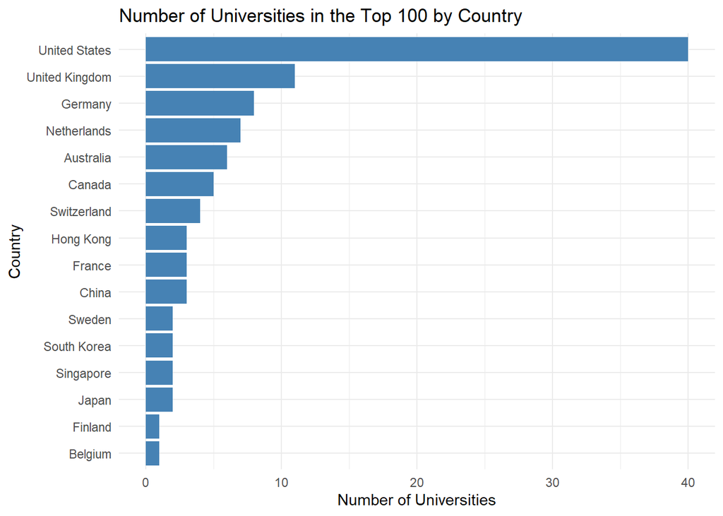

```r
ggplot(country_top100, aes(x = reorder(Country, university_count), y = university_count)) +
  geom_bar(stat = "identity", fill = "steelblue") +
  coord_flip() +
  labs(title = "Number of Universities in the Top 100 by Country",
       x = "Country",
       y = "Number of Universities")+
  theme_minimal()
```

**Answer for question_1: The United States has most number of universities in rank of top 100.**

**Data 3** **Third data is about the population data from 2019 US Census, and also includes latitude and longitude data for each state’s capital city.**

```r
#view data 3

file3 <- "https://raw.githubusercontent.com/Jennyjjxxzz/Data-607_Project2/refs/heads/main/wide_data/2019_Census_US_Population_Data_By_State_Lat_Long.csv"
df3 <- read.csv(file3)
head(df3)
```

```
##        STATE POPESTIMATE2019      lat       long
## 1    Alabama         4903185 32.37772  -86.30057
## 2     Alaska          731545 58.30160 -134.42021
## 3    Arizona         7278717 33.44814 -112.09696
## 4   Arkansas         3017804 34.74661  -92.28899
## 5 California        39512223 38.57667 -121.49363
## 6   Colorado         5758736 39.73923 -104.98486
```

**Question_1: Which states have the highest and lowest population estimates in 2019?**

```r
#The state with the highest population in 2019
highest_population_state <- df3 %>%
  arrange(desc(POPESTIMATE2019)) %>%
  slice(1)

print(highest_population_state)
```

```
##        STATE POPESTIMATE2019      lat      long
## 1 California        39512223 38.57667 -121.4936
```

```r
#The state with the lowest population in 2019
lowest_population_state <- df3 %>%
  arrange(POPESTIMATE2019) %>%
  slice(1)

print(lowest_population_state)
```

```
##     STATE POPESTIMATE2019      lat      long
## 1 Wyoming          578759 41.14026 -104.8202
```